# 분류 알고리즘

- 필요한 패키지: `rpart`, `ROCR`, `e1071`, `mlbench`

## 4.1 이항 분류 문제

#### 이항분류기 성능 측도

이항 분류는 이항 형태(success-failure, positive-negative, true-false)의 라벨과 feature 간의 패턴을 학습한 기계를 이용해 예측에 활용하는 것을 가리킨다. 강의 초반에 소개한 이항 분류기 성능에 대한 측도들을 상기해보자.

$$\begin{eqnarray*}
{\rm Accuracy} &=& \frac{\rm TP + TN}{N} \\
{\rm Precision} &=& \frac{\rm TP}{\rm TP + FP}\\
{\rm Recall} &=& \frac{\rm TP}{\rm TP + FN} = {\rm Sensitivity}\\
{\rm Specificity} &=& \frac{\rm TN}{\rm TN + FP}
\end{eqnarray*}$$

```r
harmonic.mean <- function(a, b) 2*a*b/(a+b)

accuracyMeasures <- function(pred, truth, name = "model", cutoff = 0.5) {
  ctable <- table(Actual = truth,
                  Predicted = 1*(pred >= cutoff))
  print(ctable)
  accuracy <- sum(diag(ctable))/sum(ctable)
  specificity <- ctable[1, 1]/sum(ctable[1,])
  precision <- ctable[2, 2]/sum(ctable[,2])
  recall <- ctable[2, 2]/sum(ctable[2,])
  f1 <- harmonic.mean(precision, recall)
  data.frame(model = name,
             accuracy = accuracy,
             specificity = specificity,
             sensitivity = recall,
             precision = precision,
             recall = recall,
             f1 = f1)
}
```

#### 기준값

보통 이항분류기는 예측된 클래스 확률에 적절한 기준값(criterion value, cut-off)을 적용해 분류를 실시하기 때문에, 기준값의 크기에 따라 분류 결과와 그 성능이 달라진다. 즉, 기준값을 크게 정하면 specificity는 좋아지지만 sensitivity가 떨어지고, 작게 잡으면 반대의 경우가 된다. 직관적으로 예측확률에 대해 0.5를 기준값으로 적용하는 것이 자연스러워 보이지만, 자료의 불균형이 심하거나 오분류 시 감당해야 하는 비용(리스크)를 감안해 기준값을 결정해야 한다.

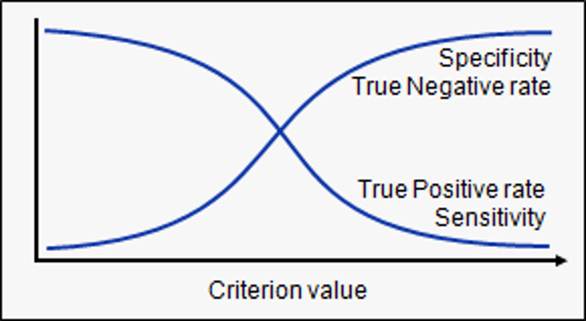

#### ROC 곡선

ROC (receive operating characteristic) 곡선은 기준값에 관계없이 이항분류기의 성능을 비교할 수 있도록 고안된 도구이다. 클래스 라벨이 0 또는 1인 경우, $y = 1$인 경우에 대해 대부분 $y = 1$인 것으로 예측을 하는 분류규칙은 sensitive하다고 하며, $y = 1$인 경우에 대해 대부분 $y = 1$인 것으로 예측을 하면 specific하다고 한다. Sensitivity와 specificity는 절단값 $c$에 따라 달라지게 된다. 이 때 다양한 절단값에 대한 ‘sensitivity’ vs ‘1-specificity’의 자취를 그려서 얻은 곡선을 ROC 곡선이라 한다. ROC 곡선 아래 면적을 AUC (area under curve)라 하는데, 이 값이 1에 가까울수록 성능이 우수한 분류기임을 의미한다.

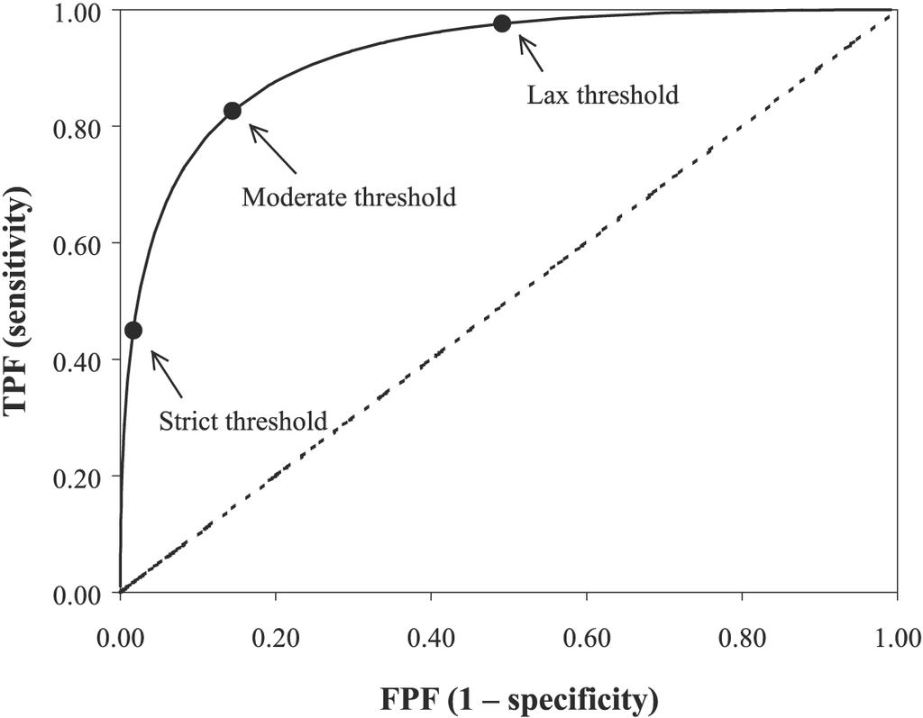

## 4.2 로지스틱 이항분류 logistic classification

회귀문제에서 배웠던 로지스틱회귀모형을 이항 분류에 활용할 수 있다. 특징변수($\mathbf x$)와 이항반응변수 $y$사이의 로지스틱 회귀모형을 적합시켜 얻은 예측확률 $p({\mathbf x})$에 대해 다음과 같은 분류 규칙을 적용하면 된다. 0과 1사이의 적당한 기준값 $c$를 기준으로

- $p(x) \ge c$ 이면 자료를 $y = 1$인 클래스로 분류
- $p(x) < c$이면 $y = 0$인 클래스로 분류

기준값 $c$의 선택을 위해 사전정보를 활용하거나 오분류에 의한 손실 정도를 클래스별로 비교 분석해 정하는 방법 등을 생각할 수 있다. 불균형 자료(unbalanced data) 즉 $y = 1$인 그룹과 $y = 0$인 그룹의 크기가 많이 차이 나는 경우 분류 성능을 위해 다소 극단적으로 보이는 기준치를 사용하기도 한다.

#### 예제데이터 분석: `adult`

- 데이터 읽기

```r
# adult <- read.csv(file = "https://archive.ics.uci.edu/ml/machine-learning-databases/adult/adult.data")
# write.csv(adult, "./dat/adult.csv", row.names = FALSE)
adult <- read.csv(file = "./dat/adult.csv")
names(adult) <- c("age", "workclass", "fnlwgt", "education", "education_num",
                  "marital_status", "occupation", "relationship", "race", "sex",
                  "capital_gain", "capital_loss", "hours_per_week",
                  "native_country", "wage")

summary(adult)
```

```
##       age                    workclass         fnlwgt
##  Min.   :17.00    Private         :22696   Min.   :  12285
##  1st Qu.:28.00    Self-emp-not-inc: 2541   1st Qu.: 117832
##  Median :37.00    Local-gov       : 2093   Median : 178363
##  Mean   :38.58    ?               : 1836   Mean   : 189782
##  3rd Qu.:48.00    State-gov       : 1297   3rd Qu.: 237054
##  Max.   :90.00    Self-emp-inc    : 1116   Max.   :1484705
##                  (Other)          :  981
##          education     education_num                  marital_status
##   HS-grad     :10501   Min.   : 1.00    Divorced             : 4443
##   Some-college: 7291   1st Qu.: 9.00    Married-AF-spouse    :   23
##   Bachelors   : 5354   Median :10.00    Married-civ-spouse   :14976
##   Masters     : 1723   Mean   :10.08    Married-spouse-absent:  418
##   Assoc-voc   : 1382   3rd Qu.:12.00    Never-married        :10682
##   11th        : 1175   Max.   :16.00    Separated            : 1025
##  (Other)      : 5134                    Widowed              :  993
##             occupation            relationship
##   Prof-specialty :4140    Husband       :13193
##   Craft-repair   :4099    Not-in-family : 8304
##   Exec-managerial:4066    Other-relative:  981
##   Adm-clerical   :3769    Own-child     : 5068
##   Sales          :3650    Unmarried     : 3446
##   Other-service  :3295    Wife          : 1568
##  (Other)         :9541
##                   race            sex         capital_gain
##   Amer-Indian-Eskimo:  311    Female:10771   Min.   :    0
##   Asian-Pac-Islander: 1039    Male  :21789   1st Qu.:    0
##   Black             : 3124                   Median :    0
##   Other             :  271                   Mean   : 1078
##   White             :27815                   3rd Qu.:    0
##                                              Max.   :99999
##
##   capital_loss     hours_per_week         native_country      wage
##  Min.   :   0.00   Min.   : 1.00    United-States:29169    <=50K:24719
##  1st Qu.:   0.00   1st Qu.:40.00    Mexico       :  643    >50K : 7841
##  Median :   0.00   Median :40.00    ?            :  583
##  Mean   :  87.31   Mean   :40.44    Philippines  :  198
##  3rd Qu.:   0.00   3rd Qu.:45.00    Germany      :  137
##  Max.   :4356.00   Max.   :99.00    Canada       :  121
##                                    (Other)       : 1709
```

- 훈련데이터와 시험데이터 쪼개기 (70:30)

```r
set.seed(0)
N <- nrow(adult)
n.tr <- round(0.7*N)
tr <- sort(sample(1:N, n.tr, replace = FALSE))
adult.tr <- adult[tr,]
adult.te <- adult[-tr,]
```

- 로지스틱회귀모형 학습

```r
glm.fit <- glm(wage ~ ., data = adult.tr, family = binomial)
```

- 예측 & 평가

```r
Actual <- 1*(adult.te$wage == " >50K")
Pr.glm <- predict(glm.fit, newdata = adult.te, type = "response")
accuracyMeasures(pred = Pr.glm, truth = Actual, cutoff = 0.5,
                 name = "Logistic with cutoff = 0.5")
```

```
##       Predicted
## Actual    0    1
##      0 6952  507
##      1  892 1417
```

```
##                        model  accuracy specificity sensitivity precision
## 1 Logistic with cutoff = 0.5 0.8567772   0.9320284   0.6136856 0.7364865
##      recall        f1
## 1 0.6136856 0.6695015
```

```r
accuracyMeasures(pred = Pr.glm, truth = Actual, cutoff = 0.3,
                 name = "Logistic with cutoff = 0.3")
```

```
##       Predicted
## Actual    0    1
##      0 6303 1156
##      1  461 1848
```

```
##                        model  accuracy specificity sensitivity precision
## 1 Logistic with cutoff = 0.3 0.8344595   0.8450194   0.8003465 0.6151798
##      recall        f1
## 1 0.8003465 0.6956522
```

- ROC curve

```r
library(ROCR)
```

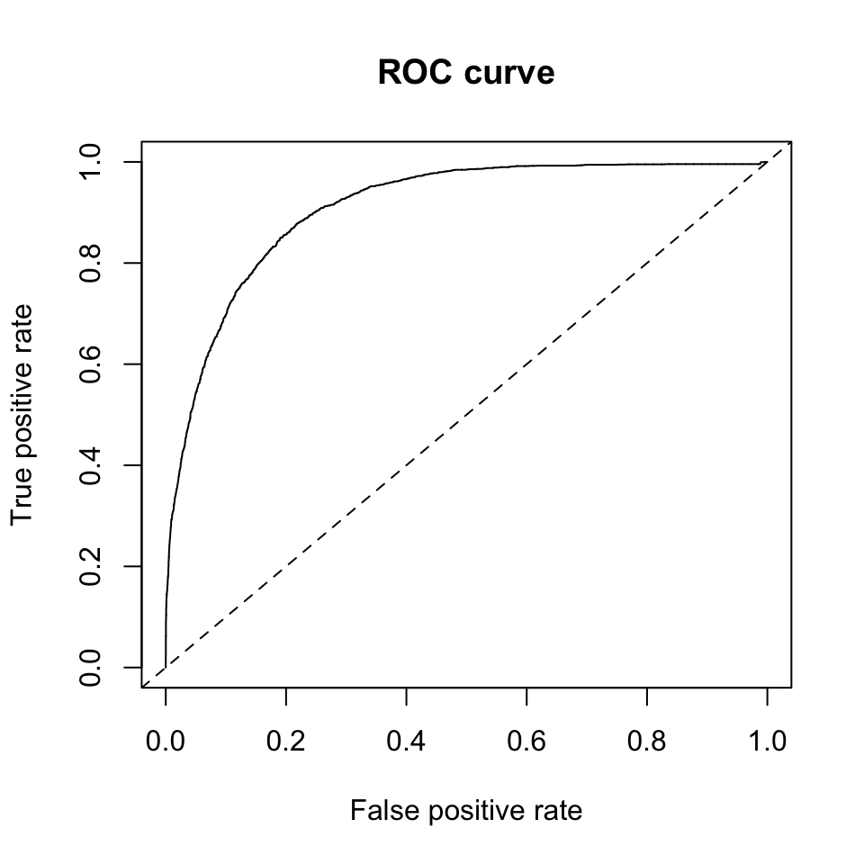

```r
Pred.glm <- prediction(Pr.glm, Actual)
Perf.glm <- performance(Pred.glm, measure = "tpr", x.measure = "fpr")

plot(Perf.glm, main = "ROC curve")
abline(0, 1, lty = 2)
```

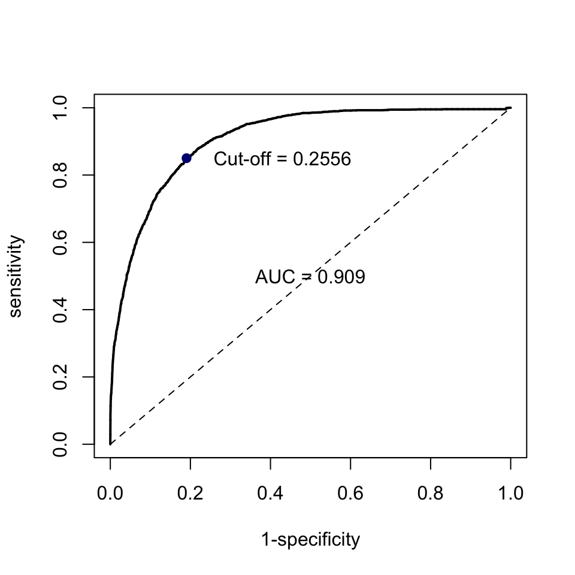

```r
library(fmsb)

roc.obj <- roc(Pr.glm, Actual, maxdist = FALSE)
best.cutoff <- roc.obj$cutoff[which.min(roc.obj$distance)]
best.specificity <- 1 - roc.obj$falsepos[which.min(roc.obj$distance)]
best.sensitivity <- roc.obj$sens[which.min(roc.obj$distance)]

plot(roc.obj)
points(1 - best.specificity, best.sensitivity, pch = 19, col = "navy")
text(1 - best.specificity + 0.24, best.sensitivity,
     paste("Cut-off = ", round(best.cutoff, 4), sep = ""))
text(0.5, 0.5,
     paste("AUC = ", round(sum(roc.obj$aucpiece), 4), sep = ""))
```

```r
accuracyMeasures(pred = Pr.glm, truth = Actual, cutoff = best.cutoff,
                 name = "Logistic with the best cutoff")
```

```
##       Predicted
## Actual    0    1
##      0 6039 1420
##      1  346 1963
```

```
##                           model  accuracy specificity sensitivity
## 1 Logistic with the best cutoff 0.8192056    0.809626   0.8501516
##   precision    recall      f1
## 1 0.5802542 0.8501516 0.68974
```

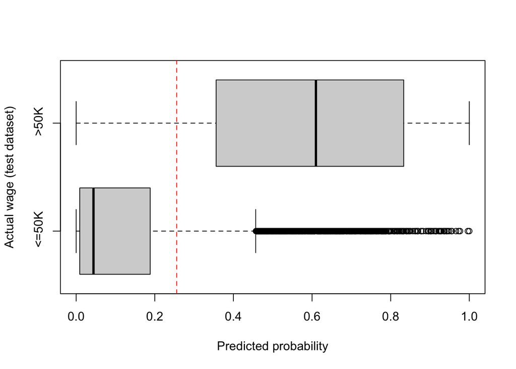

```r
boxplot(Pr.glm ~ adult.te$wage,
        xlab = "Predicted probability",
        ylab = "Actual wage (test dataset)",
        horizontal = TRUE, col = "lightgray")
abline(v = best.cutoff, col = 2, lty = 2)
```

```r
#abline(v = 0.5, col = 4, lty = 2)
```

## 4.3 의사결정나무 decision tree

의사결정나무는 예측변수 $x_1, x_2,... x_p$로 이루어진 $p$ 차원 공간을 재귀적으로 분할해 얻은 사각형 영역 $R_1, R_2,..., R_M$을 예측에 사용하는 방법이다. 각 분할(split)에서는 예측변수 중 하나만을 기준으로 사용되는데, 분할 규칙은 분할 후 영역 내의 동질성(homogeneity)를 최대로 하는 방식을 따른다. 분할된 영역의 경계가 선형이 아니기 때문에 로지스틱 분류나 LDA보다 좀더 유연한 분할 규칙을 제공한다.

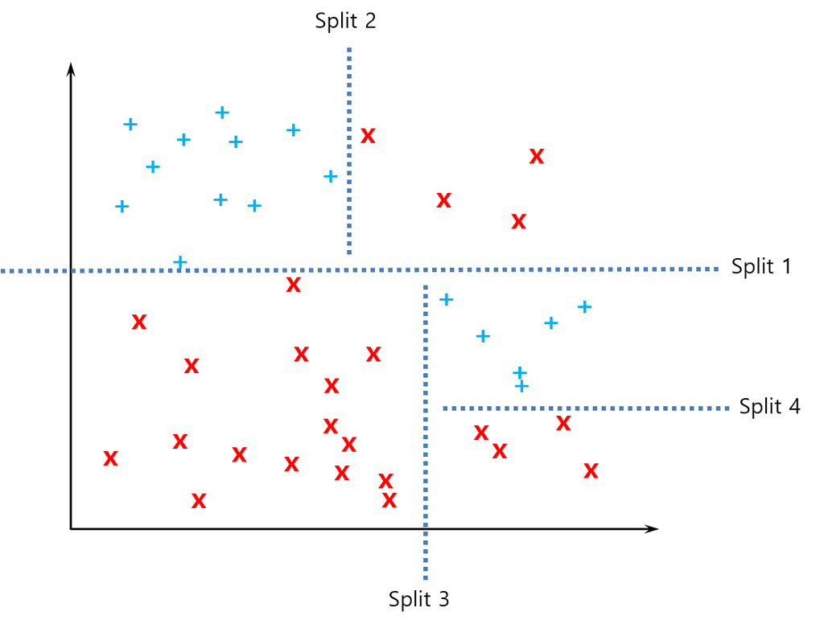

- 학습 원리
  - Regression tree와 classification tree가 있으나 classification tree에 초점을 맞춰 설명을 진행함
  - 기본 원리
    - Split 후 영역 내 **homogeneity** 를 최대로 함
  - 측도
    - 오분류율: 각 영역 내 오분류율 계산
      - Tree가 커지면 민감도(sensitivity)가 떨어짐
    - Gini impurity: 각 영역 내 클래스별 상대도수를 $p(k)$라 하면
      $$G(p) = \sum_{k=1}^K p(k) (1-p(k)) = 1 - \sum_{k=1}^K p(k)^2$$
      - $p(k)$들이 0 또는 1 에 가까워지면 $G$의 값이 작아짐 (영역 내 purity)
    - Cross-entropy
      $$D(p) = -\sum_{k=1}^K p(k)\log_2 p(k)$$
      - Gini impurity와 같은 성격: $p(k)$들이 0 또는 1 에 가까워지면 $D(p)$의 값이 작아짐
    - Information gain: Split에 의한 Entropy 감소량을 최대로 하는 방법
      $$IG(p, a) = D(p) - D(p|a)$$
      단, $D(p|a) = -\sum_a P(a) \sum_{k=1}^K p(k|a)\log_2 p(k|a)$는 split 후 엔트로피의 가중합
    - Variance reduction: (전체 영역을 대상으로 구한 분산) - (Split된 영역 내 분산의 합) 을 최대로 하는 splitting rule 을 찾음
      - Regression tree에 사용

최신 분류기에 비해 다소 예측력은 떨어지지만 도출된 분할 규칙이 이해하기 쉽고 해석이 용이하기 때문에 널리 사용되고 있다.

#### 예제 데이터 분석: `adult`

- 데이터 읽기

```r
adult <- read.csv(file = "./dat/adult.csv")
#summary(adult)
```

- 훈련데이터와 시험데이터 쪼개기 (70:30)

```r
set.seed(0)
N <- nrow(adult)
n.tr <- round(0.7*N)
tr <- sort(sample(1:N, n.tr, replace = FALSE))
adult.tr <- adult[tr,]
adult.te <- adult[-tr,]
```

- 의사결정나무 학습: `rpart` 패키지의 `rpart()` 사용

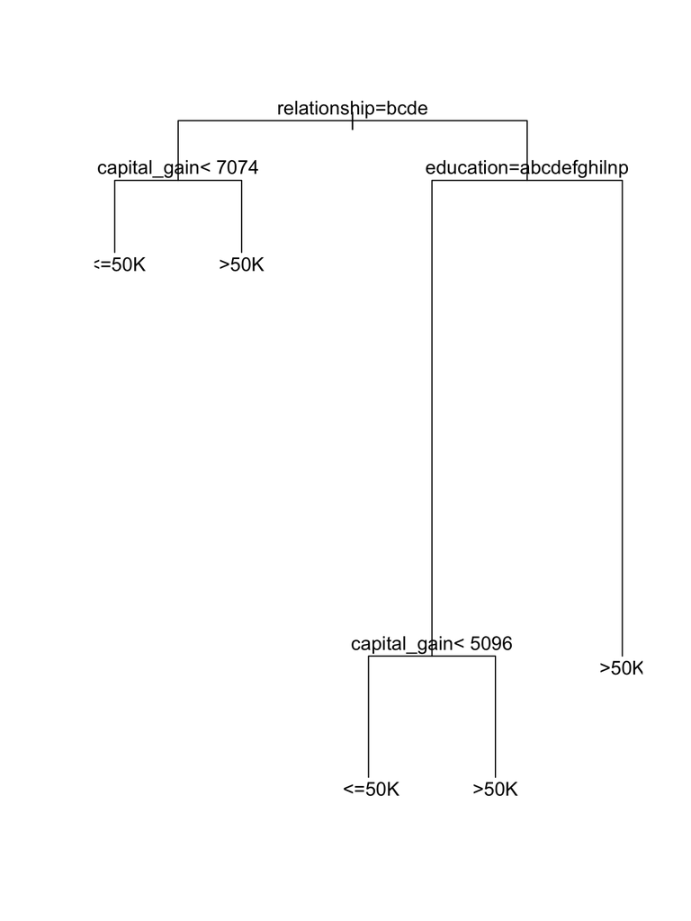

```r
library(rpart)

tree.fit <- rpart(wage ~ ., data = adult.tr)

plot(tree.fit)
text(tree.fit)
```

- 예측

```r
Actual <- 1*(adult.te$wage == " >50K")
Pr.tree <- predict(tree.fit, newdata = adult.te)[,2]
Predicted.tree <-  1*(Pr.tree >= 0.5)
table(Actual, Predicted.tree)
```

```
##       Predicted.tree
## Actual    0    1
##      0 7109  350
##      1 1085 1224
```

- 평가

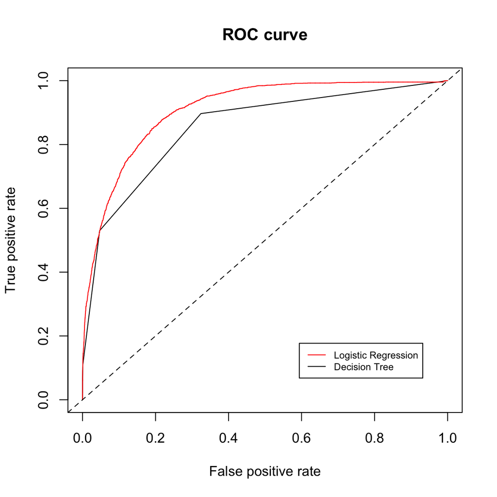

```r
library(ROCR)

Pred.tree <- prediction(Pr.tree, Actual)
Perf.tree <- performance(Pred.tree, measure = "tpr", x.measure = "fpr")
plot(Perf.tree, main = "ROC curve", cex.axis = 0.7)
plot(Perf.glm, col = "red", add = TRUE)
abline(0, 1, lty = 2)
legend("bottomright", inset = .1, cex = 0.7,
       legend = c("Logistic Regression", "Decision Tree"),
       col = c("red", "black"), lty = c(1, 1))
```

```r
performance(Pred.tree, "auc")@y.values[[1]]
```

```
## [1] 0.8535981
```

## 4.4 나이브베이즈 naive Bayes

베이지안 통계학은 관심이 있는 모든 것(모수, 결측치 등)들은 불확실하며 이 불확실의 정도는 확률을 이용해 표현된다는 가정으로부터 출발한다. 따라서 베이지안 통계학의 목표는 주어진 자료를 통하여 관심의 대상이 되는 모수의 불확실성(uncertainty)을 확률분포로 나타내는 것이다. 이 때, 모수의 불확실성에 대한 주관적인 견해를 확률로써 표현한 것을 *사전확률(prior probability)*이라 하며, 사전분포와 실험의 결과를 종합하여 새로이 구하여진 모수의 불확실성을 나타낸 확률을 *사후확률(posterior probability)*이라 한다. 즉, 베이지안 추론의 목표는 사전분포를 데이터를 활용해 사후분포로 갱신하는 것이라 할 수 있다.

나이브베이즈 분류기(Naive Bayes classifier)는

1. 클래스별 사전확률을 $P(C_1)$, $P(C_2)$, $\cdots$, $P(C_K)$을
2. 데이터에 의해 주어지는 우도(likelihood) $P({\mathbf x}|C_1)$, $P({\mathbf x}|C_2)$, $\cdots$, $P({\mathbf x}|C_K)$와 베이즈 정리를 이용해 결합해,
3. 클래스별 사후확률 $P(C_1|{\mathbf x})$, $P(C_2|{\mathbf x})$, $\cdots$, $P(C_K|{\mathbf x})$을 계산하고

$$\begin{eqnarray*}
P(C_1|{\mathbf x}) &=& \frac{P(C_1)P({\mathbf x}|C_1)}
{\sum_{k=1}^K P(C_k)P({\mathbf x}|C_k)},\\
P(C_2|{\mathbf x}) &=& \frac{P(C_2)P({\mathbf x}|C_2)}
{\sum_{k=1}^K P(C_k)P({\mathbf x}|C_k)},\\
& & \vdots \\
P(C_K|{\mathbf x}) &=& \frac{P(C_K)P({\mathbf x}|C_K)}
{\sum_{k=1}^K P(C_k)P({\mathbf x}|C_k)}
\end{eqnarray*}$$

4. 클래스별 사후확률을 비교해 가장 높은 클래스로 분류하는 알고리즘이다.

이 방법은 범주형으로 된 feature가 많이 포함되어 있는 경우에 특히 효과적으로 활용할 수 있는 classifier이다. 사전에 튜닝이 필요한 하이퍼파라미터가 없고, 비교적 차원 문제에 영향을 받지 않는다는 장점이 있다.

#### 예제 데이터 분석: `HouseVotes84`

이 데이터는 `mlbench` 패키지에 내장된 데이터셋이다. 아래 정리된 17개 변수에 대해 435개의 관측치를 모은 데이터이다.

- Class Name: 2 (democrat, republican)
- handicapped-infants: 2 (y,n)
- water-project-cost-sharing: 2 (y,n)
- adoption-of-the-budget-resolution: 2 (y,n)
- physician-fee-freeze: 2 (y,n)
- el-salvador-aid: 2 (y,n)
- religious-groups-in-schools: 2 (y,n)
- anti-satellite-test-ban: 2 (y,n)
- aid-to-nicaraguan-contras: 2 (y,n)
- mx-missile: 2 (y,n)
- immigration: 2 (y,n)
- synfuels-corporation-cutback: 2 (y,n)
- education-spending: 2 (y,n)
- superfund-right-to-sue: 2 (y,n)
- crime: 2 (y,n)
- duty-free-exports: 2 (y,n)
- export-administration-act-south-africa: 2 (y,n)

`e1071` 패키지의 `naiveBayes()` 함수를 이용해 분석해 보자.

- 데이터

```r
library(e1071)

data(HouseVotes84, package = "mlbench")
summary(HouseVotes84)
```

```
##         Class        V1         V2         V3         V4         V5
##  democrat  :267   n   :236   n   :192   n   :171   n   :247   n   :208
##  republican:168   y   :187   y   :195   y   :253   y   :177   y   :212
##                   NA's: 12   NA's: 48   NA's: 11   NA's: 11   NA's: 15
##     V6         V7         V8         V9        V10        V11
##  n   :152   n   :182   n   :178   n   :206   n   :212   n   :264
##  y   :272   y   :239   y   :242   y   :207   y   :216   y   :150
##  NA's: 11   NA's: 14   NA's: 15   NA's: 22   NA's:  7   NA's: 21
##    V12        V13        V14        V15        V16
##  n   :233   n   :201   n   :170   n   :233   n   : 62
##  y   :171   y   :209   y   :248   y   :174   y   :269
##  NA's: 31   NA's: 25   NA's: 17   NA's: 28   NA's:104
```

- 나이브베이즈 모형 학습

```r
NB <- naiveBayes(Class ~ ., data = HouseVotes84)
```

- 예측

```r
predict(NB, newdata = HouseVotes84[1:5,])
```

```
## [1] republican republican republican democrat   democrat
## Levels: democrat republican
```

```r
predict(NB, newdata = HouseVotes84[1:5,], type = "raw")
```

```
##          democrat  republican
## [1,] 1.029209e-07 0.999999897
## [2,] 5.820415e-08 0.999999942
## [3,] 5.684937e-03 0.994315063
## [4,] 9.985798e-01 0.001420152
## [5,] 9.666720e-01 0.033328022
```

```r
pred <- predict(NB, HouseVotes84)
table(pred, HouseVotes84$Class)
```

```
##
## pred         democrat republican
##   democrat        238         13
##   republican       29        155
```

#### 예제 데이터 분석: `Glass`

물론 feature에 연속형이 섞인 경우도 활용 가능하다. 이번에는 `mlbench` 패키지에 내장된 `Glass` 데이터를 분석해보자.

- RI: refractive index
- Na: Sodium
- Mg: Magnesium
- Al: Aluminum
- Si: Silicon
- K: Potassium
- Ca: Calcium
- Ba: Barium
- Fe: Iron
- Type: Type of glass (class attribute)
- 데이터

```r
data(Glass, package = "mlbench")
str(Glass)
```

```
## 'data.frame':    214 obs. of  10 variables:
##  $ RI  : num  1.52 1.52 1.52 1.52 1.52 ...
##  $ Na  : num  13.6 13.9 13.5 13.2 13.3 ...
##  $ Mg  : num  4.49 3.6 3.55 3.69 3.62 3.61 3.6 3.61 3.58 3.6 ...
##  $ Al  : num  1.1 1.36 1.54 1.29 1.24 1.62 1.14 1.05 1.37 1.36 ...
##  $ Si  : num  71.8 72.7 73 72.6 73.1 ...
##  $ K   : num  0.06 0.48 0.39 0.57 0.55 0.64 0.58 0.57 0.56 0.57 ...
##  $ Ca  : num  8.75 7.83 7.78 8.22 8.07 8.07 8.17 8.24 8.3 8.4 ...
##  $ Ba  : num  0 0 0 0 0 0 0 0 0 0 ...
##  $ Fe  : num  0 0 0 0 0 0.26 0 0 0 0.11 ...
##  $ Type: Factor w/ 6 levels "1","2","3","5",..: 1 1 1 1 1 1 1 1 1 1 ...
```

- 학습

```r
NB <- naiveBayes(Type ~ ., data = Glass)
```

- 예측

```r
predict(NB, newdata = Glass[1:5,])
```

```
## [1] 2 1 1 1 1
## Levels: 1 2 3 5 6 7
```

```r
predict(NB, newdata = Glass[1:5,], type = "raw")
```

```
##              1           2            3            5            6
## [1,] 0.3395122 0.525484444 2.971523e-05 1.471388e-05 0.1348872927
## [2,] 0.7624991 0.013424531 2.215848e-01 1.843843e-07 0.0024748630
## [3,] 0.7812094 0.031137972 1.830305e-01 7.455315e-07 0.0045743658
## [4,] 0.7039907 0.004832765 2.909401e-01 6.427938e-08 0.0002357502
## [5,] 0.8109927 0.006320305 1.821399e-01 9.916560e-08 0.0005458676
##                 7
## [1,] 7.162693e-05
## [2,] 1.655385e-05
## [3,] 4.697935e-05
## [4,] 5.456229e-07
## [5,] 1.131945e-06
```

```r
pred <- predict(NB, Glass)
table(pred, Glass$Type)
```

```
##
## pred  1  2  3  5  6  7
##    1 58 47  9  0  0  1
##    2  3 10  0  4  0  0
##    3  8  8  7  0  0  0
##    5  0  4  0  1  0  0
##    6  1  7  1  7  9 10
##    7  0  0  0  1  0 18
```

## 4.5 신경망 모형 neural network

### 4.5.1 개요

- 신경망 모형은 입력벡터 $x_1,x_2,...,x_D$와 출력벡터 $y_1,y_2,...,y_L$ 사이를 네트워크(망) 형태로 연결하는 모형이다. 뇌 신경망에서 정보를 처리하는 방식을 흉내낸 형태이기 때문에 신경망 모형이라는 이름을 갖게 되었다. 다음 그림은 $D=3$, $L=2$이고 은닉층이 두 개인 신경망모형을 나타낸 것이다.

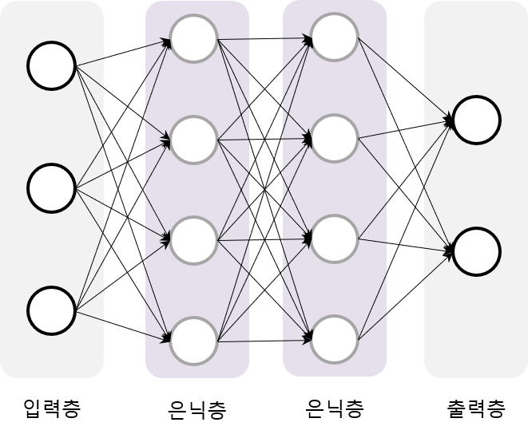

- 그림의 화살표에 해당하는 가중치를 학습해 주어진 입력값에 대응되는 출력값을 잘 예측할 수 있도록 하는 것이 관건이다. 은닉층을 여럿 쌓아서 층의 깊이를 깊게 만든 신경망 모형을 심층신경망 모형 또는 딥러닝 모형으로 부른다.

### 4.5.2 신경망 모형의 기본 개념

- 입력값 $x = (x_1, x_2,...,x_D)^\top$에 대응되는 출력값 $y = (y_1, y_2,...,y_L)^\top$ 값을 산출하는 은닉층이 하나인 순방향신경망 모형을 생각해보자

$$\begin{eqnarray*}
& & z_j = h\left(w_{j0}^{(1)} + \sum_{i = 1}^D w_{ji}^{(1)} x_i\right),\quad j=1,2,...,J\\
& & y_\ell = o\left(w_{\ell 0}^{(2)} + \sum_{j=1}^J w_{\ell j}^{(2)} z_j\right),\quad \ell = 1,2,...,L
\end{eqnarray*}$$

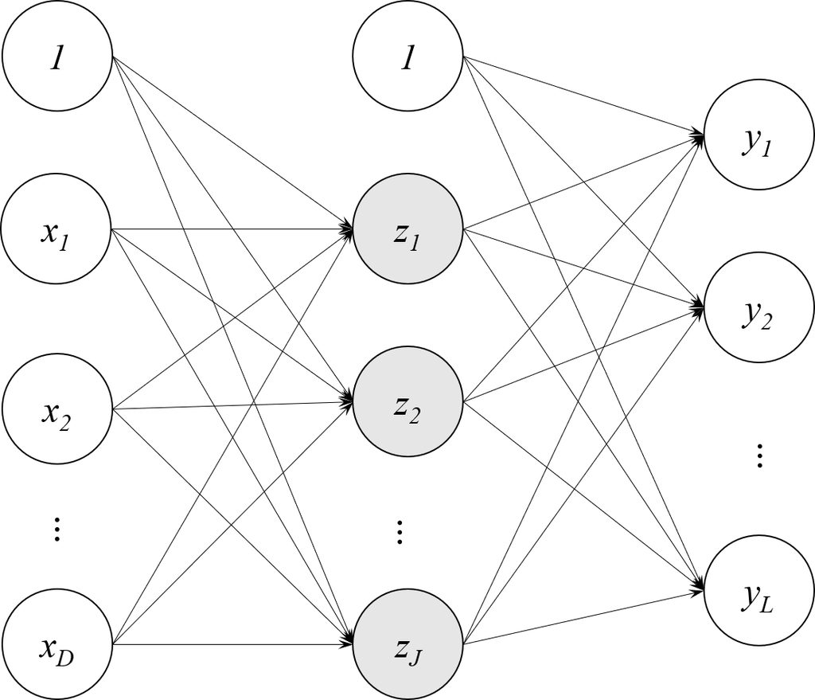

- 즉,
  $$y_\ell = f_\ell(x, w) = o\left(w_{\ell 0}^{(2)} + \sum_{j=1}^J w_{\ell j}^{(2)} h\left(w_{j0}^{(1)} + \sum_{i = 1}^D w_{ji}^{(1)} x_i\right)\right),\quad \ell = 1, 2, ..., L$$
  와 같이 비선형함수가 합성된 형태로 표현됨
- 함수 $h$는 입력값의 선형결합을 변환해 은닉노드값을 결정해주는 역할을 하는 비선형 함수로서 활성화함수(activation function)라고 부름
  - 보통 시그모이드 함수, 하이퍼탄젠트 함수, ReLU 함수 등을 사용

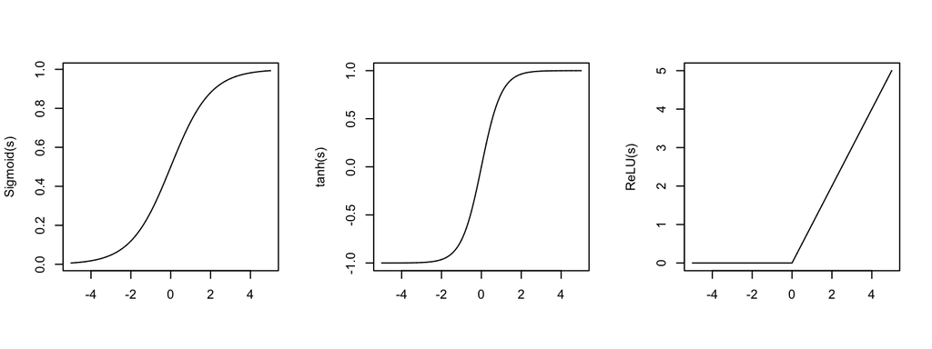

```r
Sigmoid <- function(a) 1/(1 + exp(-a))
ReLU <- function(a) pmax(a, 0)

s <- seq(from = -5, to = 5, by = 0.0025)
par(mfrow = c(1, 3))
plot(s, Sigmoid(s), type = "l", xlab = "")
plot(s, tanh(s), type = "l", xlab = "")
plot(s, ReLU(s), type = "l", xlab = "")
```

- 출력층의 활성화 함수 $o$로는 회귀문제의 경우($L = 1$) 항등함수
  $$o(a) = a$$
  를, 분류 문제의 경우 보통 소프트맥스(softmax) 함수
  $$o(a_\ell) = \frac{e^{a_\ell}}{\sum_{\ell'}e^{a_{\ell'}}}, \quad \ell = 1, 2, ..., L$$
  를 사용

#### Example: 신경망 모형을 이용한 함수 근사

- 함수 $f(x) = \frac{1}{4}x^2\quad (D = L = 1)$ 을 2-layer 신경망모형으로 근사
- 은닉층의 노드 수는 $J = 3$개로 지정
- 그림의 점선은 학습된 은닉노드 $z_1$, $z_2$, $z_3$의 실현값을 나타낸 것임
- 빨간색 점은 학습된 2-layer 신경망 모형으로 각 grid(`-2:2`)에서 계산한 근사값

```r
f <- function(x) 0.25*x^2
x <- seq(from = -2, to = 2, by = 0.005)
y <- f(x)
dat <- data.frame(x, y)

library(neuralnet)
```

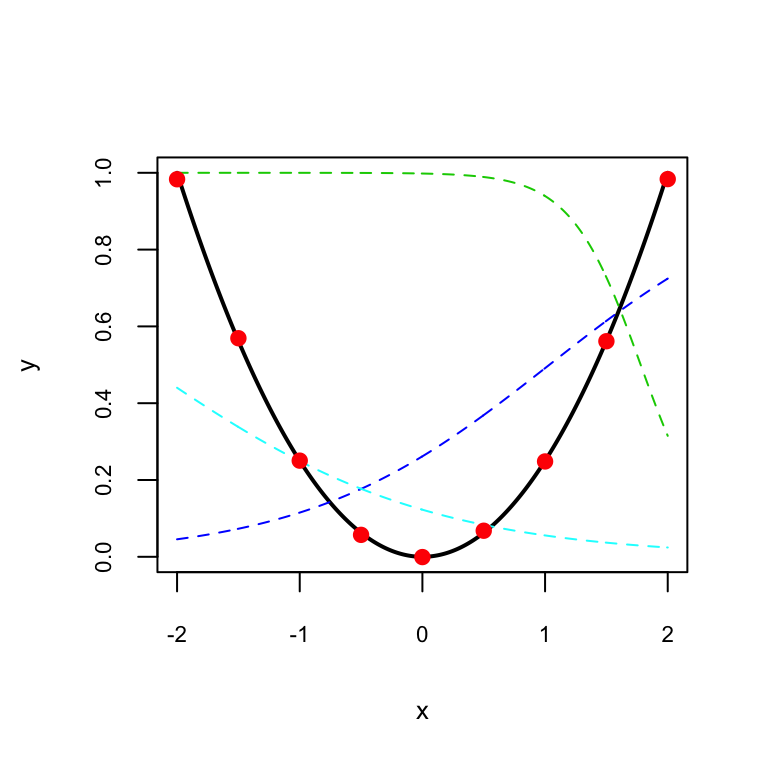

```r
set.seed(0)
h <- 3
NN <- neuralnet(y ~ x, data = dat,
                hidden = h, act.fct = "logistic",
                linear.output = TRUE)
p <- compute(NN, data.frame(x))

plot(x, y, type = "l", lwd = 2,
     cex.lab = 0.8, cex.axis = 0.7)
for ( k in 2:(h+1) )
  lines(x, p$neurons[[2]][,k], col = (k+1), lty = 2)
grid <- seq(from = 1, to = length(x), length = 9)
points(x[grid], p$net.result[grid], col = 2, pch = 19)
```

#### 예제데이터 분석: `airquality` 데이터 ($q = 1$)

- `neuralnet` 패키지 사용

```r
library(neuralnet)
```

- 데이터 표준화

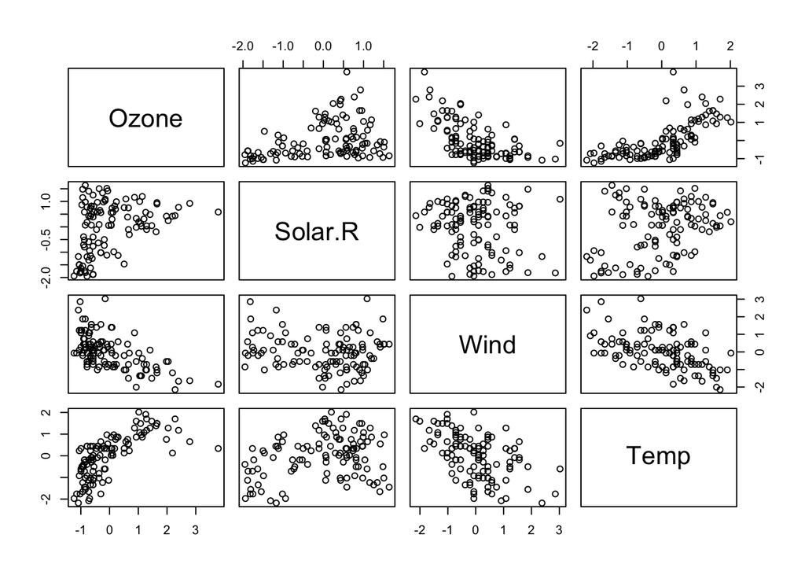

```r
dat <- na.omit(airquality[,1:4])
dat <- scale(dat)
pairs(dat[,1:4])
```

- 신경망모형 학습: 은닉층 2개, 은닉노드 개수는 두 층 모두 5개

```r
nnfit <- neuralnet(Ozone ~ Solar.R + Wind + Temp, data = dat,
                   hidden = c(5, 5), linear.output = TRUE)
pred <- compute(nnfit, dat[,2:4])$net.result
```

- 예측결과 확인: 중회귀모형과 비교

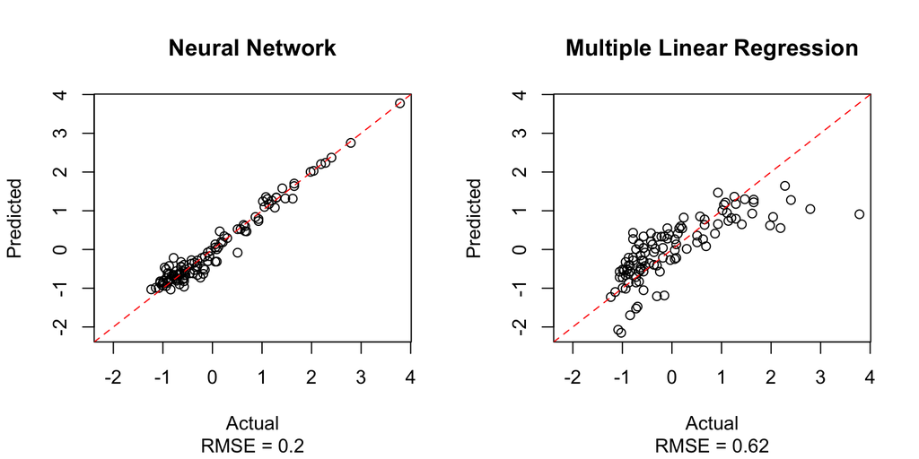

```r
X <- scale(dat[,2:4])
Y <- dat[,1]
pred.lm <- predict(lm(Y ~ X))
p <- c(pred, pred.lm)
par(mfrow = c(1,2))
plot(dat[,1], pred, xlab = "Actual", ylab = "Predicted",
     xlim = range(p), ylim = range(p), main = "Neural Network",
     sub = paste("RMSE = ", round(sqrt(mean((pred - Y)^2)), 2), sep = ""))
abline(0, 1, col = 2, lty = 2)
plot(dat[,1], pred.lm, xlab = "Actual", ylab = "Predicted",
     xlim = range(p), ylim = range(p), main = "Multiple Linear Regression",
     sub = paste("RMSE = ", round(sqrt(mean((pred.lm - Y)^2)), 2), sep = ""))
abline(0, 1, col = 2, lty = 2)
```

#### 예제데이터 분석: `infert` 데이터 ($q = 2$)

- 데이터

```r
data(infert)
# Infertility after Spontaneous and Induced Abortion
summary(infert)
```

```
##    education        age            parity         induced
##  0-5yrs : 12   Min.   :21.00   Min.   :1.000   Min.   :0.0000
##  6-11yrs:120   1st Qu.:28.00   1st Qu.:1.000   1st Qu.:0.0000
##  12+ yrs:116   Median :31.00   Median :2.000   Median :0.0000
##                Mean   :31.50   Mean   :2.093   Mean   :0.5726
##                3rd Qu.:35.25   3rd Qu.:3.000   3rd Qu.:1.0000
##                Max.   :44.00   Max.   :6.000   Max.   :2.0000
##       case         spontaneous        stratum      pooled.stratum
##  Min.   :0.0000   Min.   :0.0000   Min.   : 1.00   Min.   : 1.00
##  1st Qu.:0.0000   1st Qu.:0.0000   1st Qu.:21.00   1st Qu.:19.00
##  Median :0.0000   Median :0.0000   Median :42.00   Median :36.00
##  Mean   :0.3347   Mean   :0.5766   Mean   :41.87   Mean   :33.58
##  3rd Qu.:1.0000   3rd Qu.:1.0000   3rd Qu.:62.25   3rd Qu.:48.25
##  Max.   :1.0000   Max.   :2.0000   Max.   :83.00   Max.   :63.00
```

- 신경망모형 학습

```r
library(neuralnet)

nn.infert <- neuralnet(case ~ parity + induced + spontaneous,
                       data = infert, err.fct = "ce", hidden = c(7),
                       linear.output = FALSE)
```

- 예측결과 확인

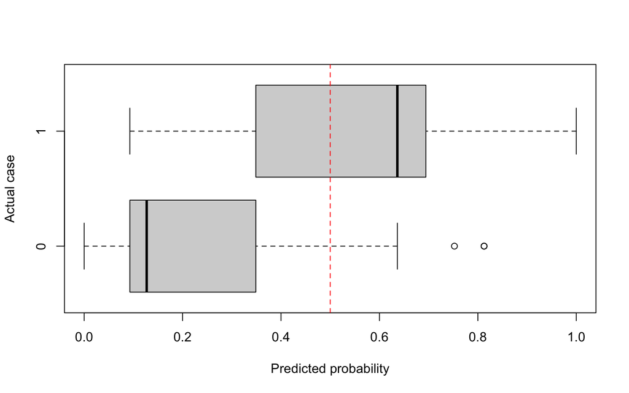

```r
x <- infert[,c("parity", "induced", "spontaneous")]
pred <- compute(nn.infert, x)$net.result
boxplot(pred ~ infert$case, col = "lightgray", horizontal = TRUE,
        xlab = "Predicted probability", ylab = "Actual case")
abline(v = 0.5, col = 2, lty = 2)
```

```r
Predicted <- 1*(pred >= 0.5)
table(Predicted, Actual = infert$case)
```

```
##          Actual
## Predicted   0   1
##         0 142  33
##         1  23  50
```